# Parenting Observational Study E1 Coding

# 2 Reliability

Import reliability coder’s data (20 participants were coded for reliability).

```r
d.long_rel <- combine_datavyu_files("rel_data/")
```

```
## [1] "120916_03_recode.csv episode with negative duration!"
```

```r
d.long_rel[which(d.long_rel$phase_length<0),]
```

```
##           SID line phase_length pja cja bid vid_duration
## 324 120916_03    7        -1275   0   1   1          209
```

```r
# SID=120916_03  line=7  -1275   0  1    1   - cja + bid, so should double-check

dim(d.long_rel %>% filter((cja==1 | pja==1) & phase_length<3000)) # 39
```

```
## [1] 39  7
```

```r
d.long_rel[which(d.long_rel$phase_length<3000),c("cja","pja")] = 0 # any episodes <3s not counted (except bids)

# summarise per subject
d.raw_rel <- d.long_rel %>% group_by(SID) %>%
  mutate(vid_duration = vid_duration / 60, # seconds to minutes
         phase_length = phase_length / 1000) %>% # ms to seconds
  summarise(bids=sum(bid), pja_length=sum(pja*phase_length), cja_length=sum(cja*phase_length),
            pja=sum(pja), cja=sum(cja), vid_duration=vid_duration[1]) %>%
  mutate(total_ja = pja + cja, total_lja = pja_length + cja_length)

# normalize to rates (e.g., bids/minute)
d.raw_rel[,2:9] = d.raw_rel[,2:9] / d.raw_rel$vid_duration
```

# 3 Reliability

```r
d.raw_rel <- d.raw_rel %>%
  mutate(bids_rel = bids, pja_rel = pja, cja_rel = cja, l_pja_rel = pja_length, l_cja_rel = cja_length) %>%
  select(SID, bids_rel, pja_rel, cja_rel, l_cja_rel, l_pja_rel)

d.raw %>% summarise(bids = mean(bids), cja=mean(cja), pja=mean(pja), l_pja=mean(pja_length), l_cja=mean(cja_length))
```

```
## # A tibble: 1 x 5
##    bids   cja   pja l_pja l_cja
##   <dbl> <dbl> <dbl> <dbl> <dbl>
## 1  4.55  2.21  1.19  8.84  25.2
```

```r
d.raw <- d.raw %>% mutate(l_pja = pja_length, l_cja = cja_length)
# 110416_03 l_cja_rel = -25889, which shouldn't be possible (incomplete final row of file)
# 121516_01 has NA bids_rel, pja_rel, and cja_rel..
# 111716_08 l_cja = -49923, which shouldn't be possible

# 110416_05, 050116_01, and 092216_03: reliability coder saw no passive JA
d_rel <- d.raw_rel %>% left_join(d.raw, by="SID") %>%
  select(SID, bids, bids_rel, pja, pja_rel, cja, cja_rel, l_cja, l_cja_rel, l_pja, l_pja_rel)


get_ICC2 <- function(dat)  {
  rel = psych::ICC(dat, missing = FALSE, alpha = 0.05)
  return(rel$results[2,])
}

bids_rel = get_ICC2(d_rel[,c("bids","bids_rel")]) # .38 [.02, .66]

pja_rel = get_ICC2(d_rel[,c("pja","pja_rel")]) # eps pass JA .06 [-.19, .36]

cja_rel = get_ICC2(d_rel[,c("cja","cja_rel")]) # eps coord JA .59 [.27, .79]

l_pja_rel = get_ICC2(d_rel[,c("l_pja","l_pja_rel")]) # pass JA length .15 [-.13, .46]

l_cja_rel = get_ICC2(d_rel[,c("l_cja","l_cja_rel")]) # coord JA length .37 [-.06, .68]

#psych::ICC(d_rel[,c("bids","bids_rel")], missing = FALSE, alpha = 0.05) # orig was ICC2=.8, now is .52
#psych::ICC(d_rel[,c("pja","pja_rel")], missing = FALSE, alpha = 0.05) # orig was ICC2=.20, now is .20 - same :/
#psych::ICC(d_rel[,c("cja","cja_rel")], missing = FALSE, alpha = 0.05) #  orig was ICC2=.66, now is .65
#psych::ICC(d_rel[,c("l_pja","l_pja_rel")], missing = FALSE, alpha = 0.05) # orig was ICC2=.24 now is .15
#psych::ICC(d_rel[,c("l_cja","l_cja_rel")], missing = FALSE, alpha = 0.05) # orig was .62 now is .28
```

# 4 Plots

Total number of bids (successful and unsuccessful)

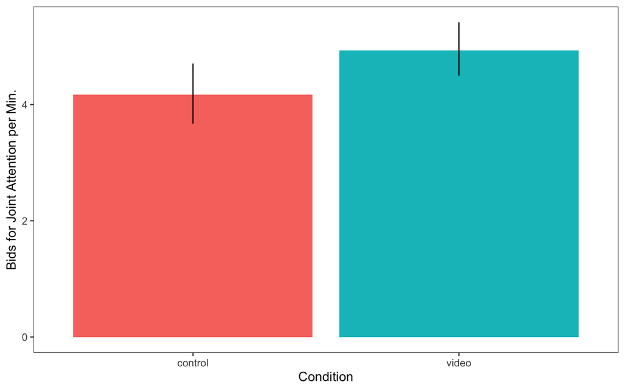

```r
save(d, file="Exp1_joint_attention_data.RData")
ms_bids <- d %>%
  group_by(Condition) %>%
  multi_boot_standard(col = "bids_tot")

ms_bids$Condition <- factor(ms_bids$Condition,
                            levels = c("con", "exp"),
                            labels = c("control", "video"))

ggplot(ms_bids, aes(x = Condition, y = mean, fill = Condition)) +
  geom_bar(stat="identity") +
  geom_linerange(aes(ymin = ci_lower, ymax = ci_upper),
             position = position_dodge(width = .9))+
  xlab("Condition") +
  ylab("Bids for Joint Attention per Min.") +
  langcog::scale_colour_solarized()  +
  ggthemes::theme_few() +
  theme(legend.position="none")
```

Total episodes of joint attention.

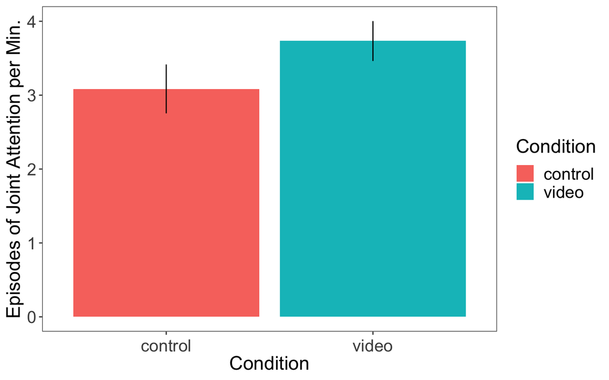

```r
ms_tja <- d %>%
  group_by(Condition) %>%
  multi_boot_standard(col = "total_ja")

ms_tja$Condition <- factor(ms_tja$Condition,
levels = c("con", "exp"),
labels = c("control", "video"))

ggplot(ms_tja, aes(x = Condition, y = mean, fill = Condition)) +
  geom_bar(stat="identity") +
  geom_linerange(aes(ymin = ci_lower, ymax = ci_upper),
             position = position_dodge(width = .9))+
  xlab("Condition") +
  ylab("Episodes of Joint Attention per Min.") +
  langcog::scale_colour_solarized()  +
  ggthemes::theme_few() +
  theme(legend.title = element_text(size=18),
        legend.text = element_text(size=16),
        axis.text.x  = element_text(vjust=0.5, size=16),
        axis.title.x = element_text(size=18),
        axis.text.y  = element_text(vjust=0.5, size=16),
        axis.title.y = element_text(size=18))
```

Episodes of passive joint attention.

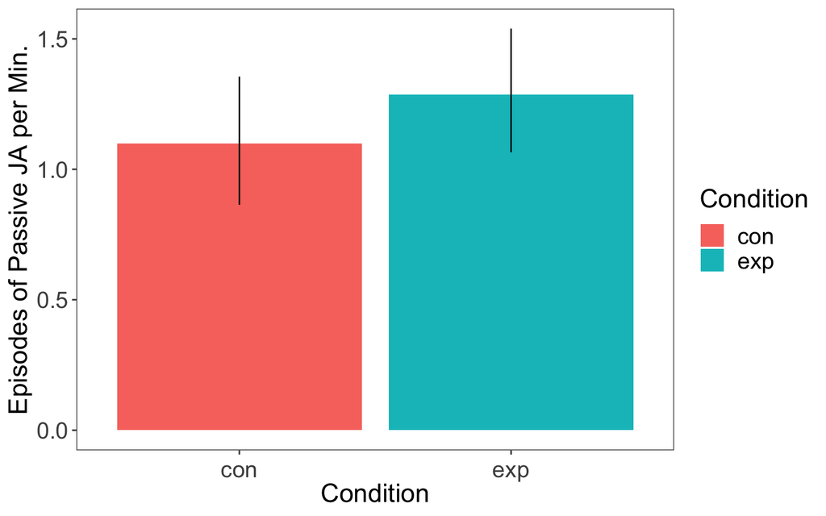

```r
ms_pja <- d %>%
  group_by(Condition) %>%
  multi_boot_standard(col = "pja")

ggplot(ms_pja, aes(x = Condition, y = mean, fill = Condition)) +
  geom_bar(stat="identity") +
  geom_linerange(aes(ymin = ci_lower, ymax = ci_upper),
             position = position_dodge(width = .9))+
  xlab("Condition") +
  ylab("Episodes of Passive JA per Min.")  +
  langcog::scale_colour_solarized() +
  theme(legend.title = element_text(size=18),
        legend.text = element_text(size=16),
        axis.text.x  = element_text(vjust=0.5, size=16),
        axis.title.x = element_text(size=18),
        axis.text.y  = element_text(vjust=0.5, size=16),
        axis.title.y = element_text(size=18))
```

Episodes of coordinated joint attention

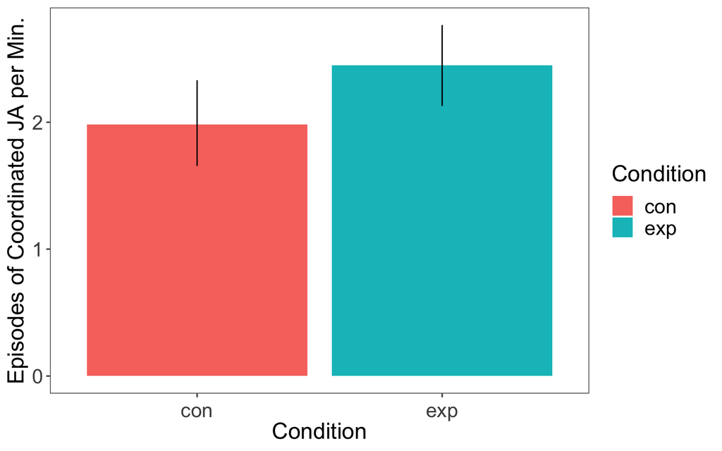

```r
ms_cja <- d %>%
  group_by(Condition) %>%
  multi_boot_standard(col = "cja")

ggplot(ms_cja, aes(x = Condition, y = mean, fill = Condition)) +
  geom_bar(stat="identity") +
  geom_linerange(aes(ymin = ci_lower, ymax = ci_upper),
             position = position_dodge(width = .9))+
  xlab("Condition") +
  ylab("Episodes of Coordinated JA per Min.")  +
  langcog::scale_colour_solarized()  +
  theme(legend.title = element_text(size=18),
        legend.text = element_text(size=16),
        axis.text.x  = element_text(vjust=0.5, size=16),
        axis.title.x = element_text(size=18),
        axis.text.y  = element_text(vjust=0.5, size=16),
        axis.title.y = element_text(size=18))
```

Total duration of passive joint attention.

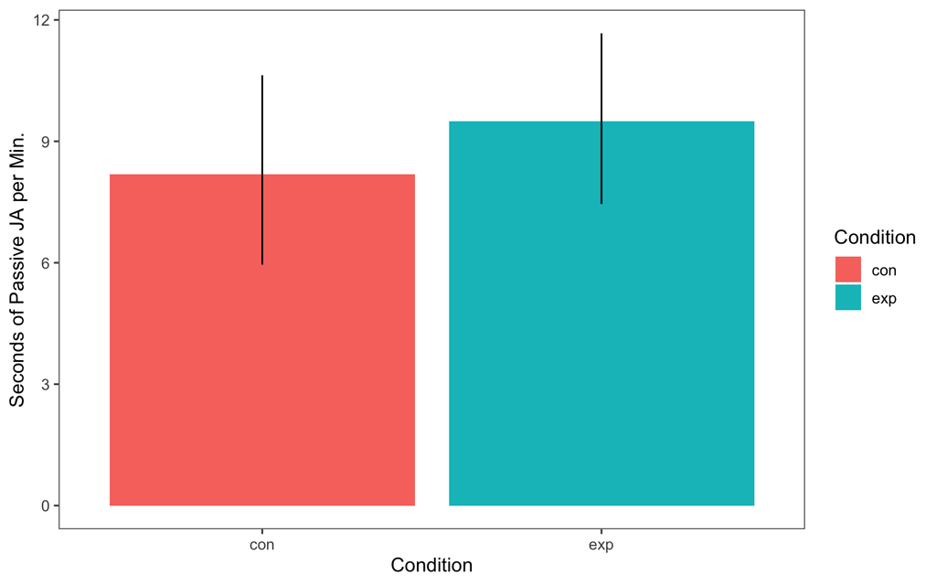

```r
ms_lpja <- d %>%
  filter(!is.na(Condition))%>%
  group_by(Condition) %>%
  multi_boot_standard(col = "pja_length")

ggplot(ms_lpja, aes(x = Condition, y = mean, fill = Condition)) +
  geom_bar(stat="identity") +
  geom_linerange(aes(ymin = ci_lower, ymax = ci_upper),
             position = position_dodge(width = .9))+
  xlab("Condition") +
  ylab("Seconds of Passive JA per Min.")  +
  langcog::scale_colour_solarized()  +
  ggthemes::theme_few()
```

Total duration of coordinated joint attention.

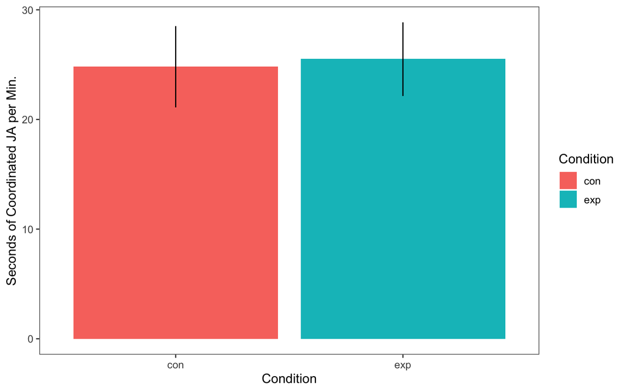

```r
ms_lcja <- d %>%
  filter(!is.na(Condition))%>%
  group_by(Condition) %>%
  multi_boot_standard(col = "cja_length")

ggplot(ms_lcja, aes(x = Condition, y = mean, fill = Condition)) +
  geom_bar(stat="identity") +
  geom_linerange(aes(ymin = ci_lower, ymax = ci_upper),
             position = position_dodge(width = .9))+
  xlab("Condition") +
  ylab("Seconds of Coordinated JA per Min.")  +
  langcog::scale_colour_solarized()  +
  ggthemes::theme_few()
```

## 4.1 Demographics

### 4.1.1 Child gender

Total bids by gender.

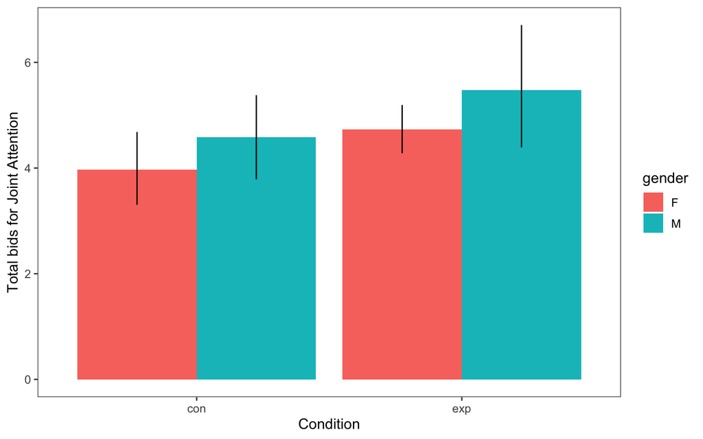

```r
# total bids
ms_bids <- d %>%
  group_by(Condition, gender) %>%
  multi_boot_standard(col = "bids_tot")

ggplot(ms_bids, aes(x = Condition, y = mean, fill=gender)) +
  geom_bar(stat="identity", position = "dodge") +
  geom_linerange(aes(ymin = ci_lower, ymax = ci_upper),
             position = position_dodge(width = .9))+
  xlab("Condition") +
  ylab("Total bids for Joint Attention")  +
  langcog::scale_colour_solarized()  +
  ggthemes::theme_few()
```

Total duration of passive joint attention by gender

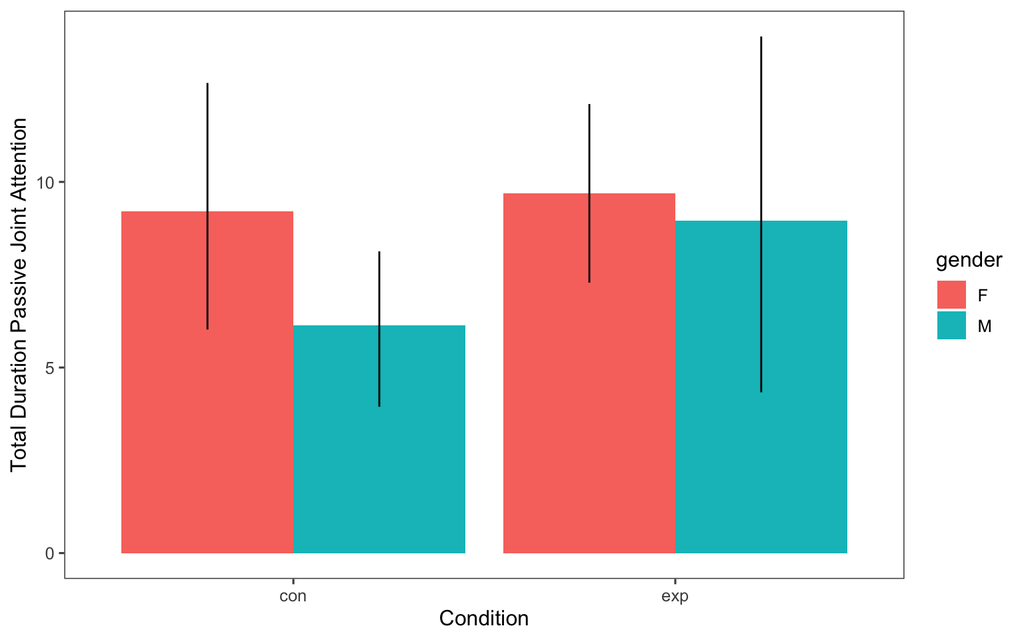

```r
ms_lpja <- d %>%
  filter(!is.na(Condition))%>%
  group_by(Condition, gender) %>%
  multi_boot_standard(col = "pja_length")

ggplot(ms_lpja, aes(x = Condition, y = mean, fill=gender)) +
  geom_bar(stat="identity", position = "dodge") +
  geom_linerange(aes(ymin = ci_lower, ymax = ci_upper),
             position = position_dodge(width = .9))+
  xlab("Condition") +
  ylab("Total Duration Passive Joint Attention")  +
  langcog::scale_colour_solarized()  +
  ggthemes::theme_few()
```

Total duration of coordinated joint attention by gender

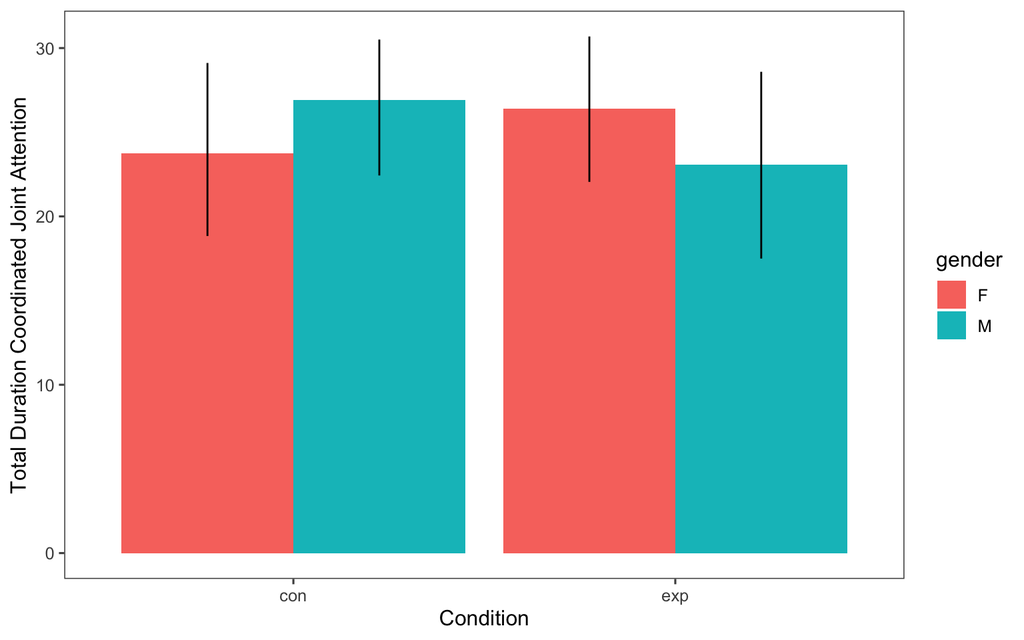

```r
ms_lcja <- d %>%
  filter(!is.na(Condition))%>%
  group_by(Condition, gender) %>%
  multi_boot_standard(col = "cja_length")

ggplot(ms_lcja, aes(x = Condition, y = mean, fill=gender)) +
  geom_bar(stat="identity", position = "dodge") +
  geom_linerange(aes(ymin = ci_lower, ymax = ci_upper),
             position = position_dodge(width = .9))+
  xlab("Condition") +
  ylab("Total Duration Coordinated Joint Attention")  +
  langcog::scale_colour_solarized()  +
  ggthemes::theme_few()
```

### 4.1.2 Child age

Children were separated into 3 age groups: 6-12 months, 12-18 months, and 18-24 months.

Total bids by age.

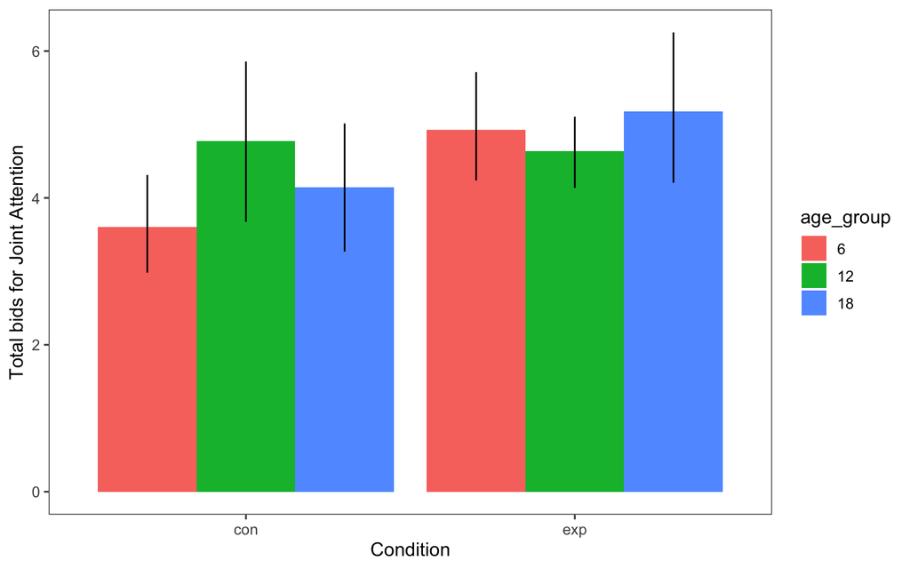

```r
# total bids
ms_bids <- d %>%
  group_by(Condition, age_group) %>%
  multi_boot_standard(col = "bids_tot")

ms_bids$age_group <- factor(ms_bids$age_group , levels = c("6","12", "18"))

ggplot(ms_bids, aes(x = Condition, y = mean, fill=age_group)) +
  geom_bar(stat="identity", position= "dodge") +
  geom_linerange(aes(ymin = ci_lower, ymax = ci_upper),
             position = position_dodge(width = .9))+
  xlab("Condition") +
  ylab("Total bids for Joint Attention")  +
  langcog::scale_colour_solarized()  +
  ggthemes::theme_few()
```

Total duration of passive joint attention by age

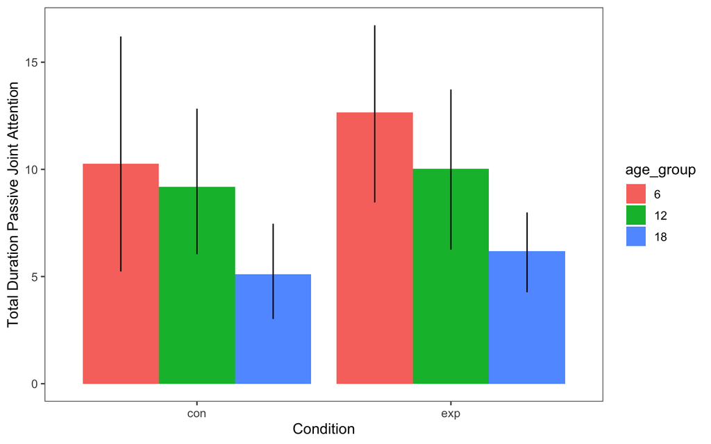

```r
ms_lpja <- d %>%
  filter(!is.na(Condition))%>%
  group_by(Condition, age_group) %>%
  multi_boot_standard(col = "pja_length")

ms_lpja$age_group <- factor(ms_lpja$age_group , levels = c("6","12", "18"))

ggplot(ms_lpja, aes(x = Condition, y = mean, fill = age_group)) +
  geom_bar(stat="identity", position = "dodge") +
  geom_linerange(aes(ymin = ci_lower, ymax = ci_upper),
             position = position_dodge(width = .9))+
  xlab("Condition") +
  ylab("Total Duration Passive Joint Attention")  +
  langcog::scale_colour_solarized()  +
  ggthemes::theme_few()
```

Total duration of coordinated joint attention by age

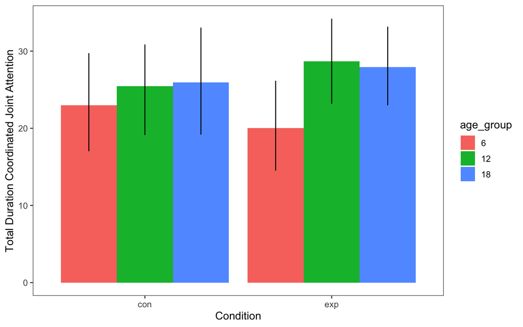

```r
ms_lcja <- d %>%
  filter(!is.na(Condition))%>%
  group_by(Condition, age_group) %>%
  multi_boot_standard(col = "cja_length")

ms_lcja$age_group <- factor(ms_lcja$age_group , levels = c("6","12", "18"))

ggplot(ms_lcja, aes(x = Condition, y = mean, fill = age_group)) +
  geom_bar(stat="identity", position = "dodge") +
  geom_linerange(aes(ymin = ci_lower, ymax = ci_upper),
             position = position_dodge(width = .9))+
  xlab("Condition") +
  ylab("Total Duration Coordinated Joint Attention")  +
  langcog::scale_colour_solarized()  +
  ggthemes::theme_few()
```

### 4.1.3 Parenting attitudes and education

Do PAQ scores predict the number of bids for joint attention by parents?

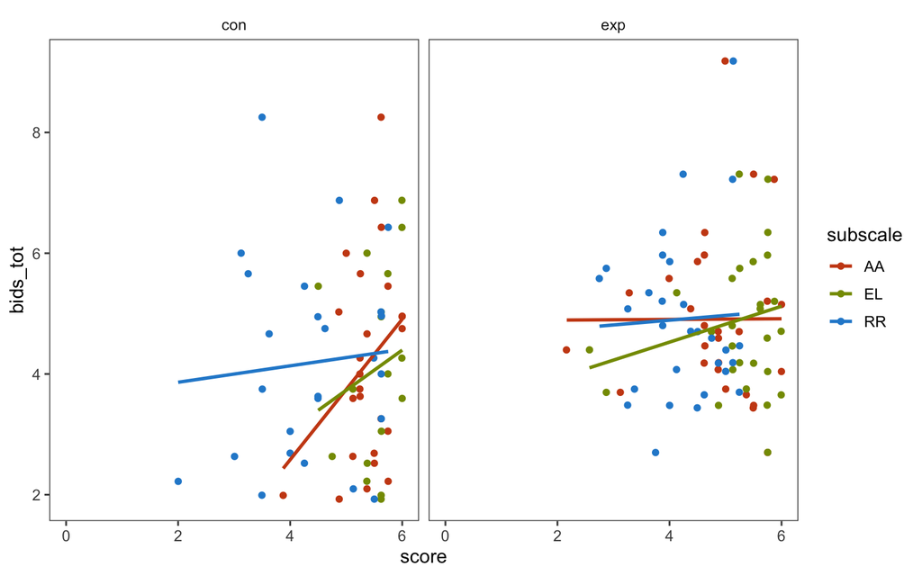

```r
d_plot <- d %>%
  gather("subscale","score", AA:RR)

ggplot(d_plot, aes(x = score, y = bids_tot, col = subscale)) +
  geom_jitter() +
  xlim(0,6) +
  geom_smooth(method="lm", se=FALSE)  +
  facet_wrap(~Condition)+
  ggthemes::theme_few() +
  langcog::scale_colour_solarized()
```

Does parent education predict the number of bids for joint attention by parents?

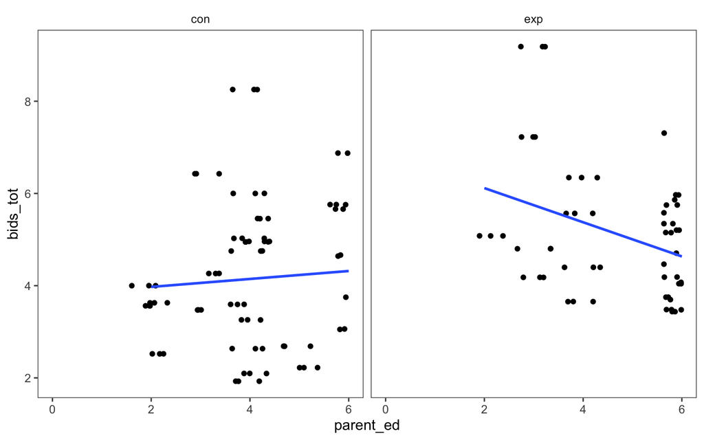

```r
d_plot <- d %>%
  gather("subscale","score", AA:RR)

ggplot(d_plot, aes(x = parent_ed, y = bids_tot)) +
  geom_jitter() +
  xlim(0,6) +
  geom_smooth(method="lm", se=FALSE)  +
  facet_wrap(~Condition)+
  ggthemes::theme_few() +
  langcog::scale_colour_solarized()
```

# 5 Analysis

Is the duration of joint attention correlated with age in months?

```r
cormat <- d %>%
  select(age_months, pja_length, cja_length, total_lja)
rcorr(as.matrix(cormat))
```

```
##            age_months pja_length cja_length total_lja
## age_months       1.00      -0.37       0.22     -0.02
## pja_length      -0.37       1.00      -0.63      0.00
## cja_length       0.22      -0.63       1.00      0.77
## total_lja       -0.02       0.00       0.77      1.00
##
## n= 60
##
##
## P
##            age_months pja_length cja_length total_lja
## age_months            0.0040     0.0979     0.8645
## pja_length 0.0040                0.0000     0.9722
## cja_length 0.0979     0.0000                0.0000
## total_lja  0.8645     0.9722     0.0000
```

Mixed effects models.

Prepare data.

```r
lmer_data <- d %>%
  filter(!is.na(AA), !is.na(EL), !is.na(RR))%>%
  mutate(Condition = factor(Condition),
         bids_tot = as.numeric(bids_tot),
         EL = as.numeric(langcog::scale(EL, scale=FALSE)),
         AA = as.numeric(langcog::scale(AA, scale=FALSE)),
         RR = as.numeric(langcog::scale(RR, scale=FALSE)),
         age = as.numeric(langcog::scale(age, scale=FALSE)),
         gender = as.factor(gender),
         Video = as.factor(Video))
```

Total number of bids

```r
maximal_mod <- lmer(bids_tot ~ Condition *  EL  + Condition * AA + Condition * RR + age + gender + parent_ed +
                           (1| Video), data = lmer_data)
summary(maximal_mod)
```

```
## Linear mixed model fit by REML. t-tests use Satterthwaite's method [
## lmerModLmerTest]
## Formula: bids_tot ~ Condition * EL + Condition * AA + Condition * RR +
##     age + gender + parent_ed + (1 | Video)
##    Data: lmer_data
##
## REML criterion at convergence: 184.8
##
## Scaled residuals:
##     Min      1Q  Median      3Q     Max
## -1.3584 -0.5454 -0.1579  0.4970  2.5716
##
## Random effects:
##  Groups   Name        Variance Std.Dev.
##  Video    (Intercept) 0.000    0.00
##  Residual             2.192    1.48
## Number of obs: 54, groups:  Video, 6
##
## Fixed effects:
##                 Estimate Std. Error       df t value Pr(>|t|)
## (Intercept)      4.23799    0.86048 43.00000   4.925 1.29e-05 ***
## Conditionexp     1.39854    0.50637 43.00000   2.762  0.00842 **
## EL               0.62287    0.84284 43.00000   0.739  0.46392
## AA               1.29472    0.68938 43.00000   1.878  0.06716 .
## RR               0.01341    0.35741 43.00000   0.038  0.97024
## age              0.23887    0.52037 43.00000   0.459  0.64852
## genderM          1.10622    0.48801 43.00000   2.267  0.02849 *
## parent_ed       -0.19328    0.18260 43.00000  -1.058  0.29575
## Conditionexp:EL -0.01568    1.03007 43.00000  -0.015  0.98793
## Conditionexp:AA -1.77606    0.87701 43.00000  -2.025  0.04909 *
## Conditionexp:RR  0.14279    0.51946 43.00000   0.275  0.78472
## ---
## Signif. codes:  0 '***' 0.001 '**' 0.01 '*' 0.05 '.' 0.1 ' ' 1
##
## Correlation of Fixed Effects:
##             (Intr) Cndtnx EL     AA     RR     age    gendrM prnt_d Cnd:EL
## Conditionxp  0.000
## EL          -0.027  0.356
## AA          -0.274  0.273 -0.098
## RR          -0.256 -0.231 -0.455 -0.011
## age          0.154  0.081  0.198 -0.137 -0.046
## genderM     -0.117  0.050 -0.085  0.179  0.162 -0.179
## parent_ed   -0.882 -0.368 -0.151  0.075  0.328 -0.153 -0.073
## Condtnxp:EL -0.112 -0.322 -0.846  0.098  0.424 -0.210  0.083  0.272
## Condtnxp:AA  0.378 -0.126  0.118 -0.820 -0.061  0.193 -0.221 -0.224 -0.348
## Condtnxp:RR  0.062  0.175  0.282  0.034 -0.638 -0.041 -0.045 -0.111 -0.198
##             Cnd:AA
## Conditionxp
## EL
## AA
## RR
## age
## genderM
## parent_ed
## Condtnxp:EL
## Condtnxp:AA
## Condtnxp:RR -0.011
## convergence code: 0
## boundary (singular) fit: see ?isSingular
```

Episodes of coordinated joint attention.

```r
maximal_mod <- lmer(cja ~ Condition *  EL  + Condition * AA + Condition * RR  + age + gender + parent_ed +
                           (1| Video), data = lmer_data)
summary(maximal_mod)
```

```
## Linear mixed model fit by REML. t-tests use Satterthwaite's method [
## lmerModLmerTest]
## Formula: cja ~ Condition * EL + Condition * AA + Condition * RR + age +
##     gender + parent_ed + (1 | Video)
##    Data: lmer_data
##
## REML criterion at convergence: 145.6
##
## Scaled residuals:
##      Min       1Q   Median       3Q      Max
## -1.80140 -0.52750 -0.01873  0.59944  1.62826
##
## Random effects:
##  Groups   Name        Variance Std.Dev.
##  Video    (Intercept) 0.2008   0.4481
##  Residual             0.7963   0.8924
## Number of obs: 54, groups:  Video, 6
##
## Fixed effects:
##                 Estimate Std. Error       df t value Pr(>|t|)
## (Intercept)      1.40915    0.59525 36.15055   2.367   0.0234 *
## Conditionexp     0.43388    0.30800 40.22405   1.409   0.1666
## EL              -0.02517    0.52500 41.91652  -0.048   0.9620
## AA               0.08005    0.43432 42.09192   0.184   0.8547
## RR               0.21431    0.21941 40.75488   0.977   0.3345
## age              0.51956    0.47787  8.99216   1.087   0.3052
## genderM          0.45116    0.30002 40.62514   1.504   0.1404
## parent_ed        0.09840    0.11881 42.92053   0.828   0.4121
## Conditionexp:EL  0.58981    0.65613 42.51758   0.899   0.3738
## Conditionexp:AA -0.39446    0.55994 42.47749  -0.704   0.4850
## Conditionexp:RR  0.08761    0.31752 40.07388   0.276   0.7840
## ---
## Signif. codes:  0 '***' 0.001 '**' 0.01 '*' 0.05 '.' 0.1 ' ' 1
##
## Correlation of Fixed Effects:
##             (Intr) Cndtnx EL     AA     RR     age    gendrM prnt_d Cnd:EL
## Conditionxp  0.006
## EL          -0.027  0.370
## AA          -0.313  0.243 -0.094
## RR          -0.274 -0.241 -0.460  0.025
## age          0.094 -0.025  0.016 -0.050  0.040
## genderM     -0.067  0.040 -0.083  0.161  0.150 -0.081
## parent_ed   -0.855 -0.349 -0.144  0.148  0.358 -0.069 -0.099
## Condtnxp:EL -0.095 -0.329 -0.851  0.077  0.429 -0.040  0.074  0.255
## Condtnxp:AA  0.414 -0.098  0.127 -0.827 -0.105  0.111 -0.201 -0.297 -0.329
## Condtnxp:RR  0.065  0.185  0.296  0.005 -0.632 -0.057 -0.037 -0.117 -0.208
##             Cnd:AA
## Conditionxp
## EL
## AA
## RR
## age
## genderM
## parent_ed
## Condtnxp:EL
## Condtnxp:AA
## Condtnxp:RR  0.019
```

Episodes of passive joint attention.

```r
maximal_mod <- lmer(pja ~ Condition *  EL  + Condition * AA + Condition * RR  + age + gender + parent_ed +
                           (1| Video), data = lmer_data)
summary(maximal_mod)
```

```
## Linear mixed model fit by REML. t-tests use Satterthwaite's method [
## lmerModLmerTest]
## Formula: pja ~ Condition * EL + Condition * AA + Condition * RR + age +
##     gender + parent_ed + (1 | Video)
##    Data: lmer_data
##
## REML criterion at convergence: 116.1
##
## Scaled residuals:
##      Min       1Q   Median       3Q      Max
## -1.42845 -0.48611 -0.08572  0.49273  2.58435
##
## Random effects:
##  Groups   Name        Variance Std.Dev.
##  Video    (Intercept) 0.0000   0.0000
##  Residual             0.4432   0.6658
## Number of obs: 54, groups:  Video, 6
##
## Fixed effects:
##                 Estimate Std. Error       df t value Pr(>|t|)
## (Intercept)      1.35037    0.38697 43.00000   3.490  0.00113 **
## Conditionexp     0.49422    0.22772 43.00000   2.170  0.03555 *
## EL               0.32263    0.37903 43.00000   0.851  0.39937
## AA               0.55338    0.31002 43.00000   1.785  0.08132 .
## RR               0.04705    0.16073 43.00000   0.293  0.77112
## age             -0.30309    0.23402 43.00000  -1.295  0.20218
## genderM          0.09719    0.21947 43.00000   0.443  0.66010
## parent_ed       -0.12179    0.08212 43.00000  -1.483  0.14534
## Conditionexp:EL -0.86661    0.46323 43.00000  -1.871  0.06819 .
## Conditionexp:AA -0.20868    0.39440 43.00000  -0.529  0.59944
## Conditionexp:RR -0.43948    0.23361 43.00000  -1.881  0.06672 .
## ---
## Signif. codes:  0 '***' 0.001 '**' 0.01 '*' 0.05 '.' 0.1 ' ' 1
##
## Correlation of Fixed Effects:
##             (Intr) Cndtnx EL     AA     RR     age    gendrM prnt_d Cnd:EL
## Conditionxp  0.000
## EL          -0.027  0.356
## AA          -0.274  0.273 -0.098
## RR          -0.256 -0.231 -0.455 -0.011
## age          0.154  0.081  0.198 -0.137 -0.046
## genderM     -0.117  0.050 -0.085  0.179  0.162 -0.179
## parent_ed   -0.882 -0.368 -0.151  0.075  0.328 -0.153 -0.073
## Condtnxp:EL -0.112 -0.322 -0.846  0.098  0.424 -0.210  0.083  0.272
## Condtnxp:AA  0.378 -0.126  0.118 -0.820 -0.061  0.193 -0.221 -0.224 -0.348
## Condtnxp:RR  0.062  0.175  0.282  0.034 -0.638 -0.041 -0.045 -0.111 -0.198
##             Cnd:AA
## Conditionxp
## EL
## AA
## RR
## age
## genderM
## parent_ed
## Condtnxp:EL
## Condtnxp:AA
## Condtnxp:RR -0.011
## convergence code: 0
## boundary (singular) fit: see ?isSingular
```

Total duration of passive joint attention.

```r
maximal_mod <- lmer(pja_length ~ Condition *  EL  + Condition * AA + Condition * RR  + age + gender + parent_ed +
                           (1| Video), data = lmer_data)
summary(maximal_mod)
```

```
## Linear mixed model fit by REML. t-tests use Satterthwaite's method [
## lmerModLmerTest]
## Formula: pja_length ~ Condition * EL + Condition * AA + Condition * RR +
##     age + gender + parent_ed + (1 | Video)
##    Data: lmer_data
##
## REML criterion at convergence: 306.2
##
## Scaled residuals:
##      Min       1Q   Median       3Q      Max
## -1.41211 -0.63259 -0.03025  0.60862  1.96624
##
## Random effects:
##  Groups   Name        Variance Std.Dev.
##  Video    (Intercept)  0.00    0.000
##  Residual             36.87    6.072
## Number of obs: 54, groups:  Video, 6
##
## Fixed effects:
##                 Estimate Std. Error      df t value Pr(>|t|)
## (Intercept)       9.9804     3.5294 43.0000   2.828  0.00709 **
## Conditionexp      3.7335     2.0770 43.0000   1.798  0.07927 .
## EL                2.1389     3.4571 43.0000   0.619  0.53938
## AA                3.1215     2.8276 43.0000   1.104  0.27577
## RR                0.3944     1.4660 43.0000   0.269  0.78921
## age              -4.0878     2.1344 43.0000  -1.915  0.06213 .
## genderM          -0.5209     2.0017 43.0000  -0.260  0.79593
## parent_ed        -0.8506     0.7490 43.0000  -1.136  0.26241
## Conditionexp:EL  -5.1329     4.2250 43.0000  -1.215  0.23104
## Conditionexp:AA  -1.5539     3.5972 43.0000  -0.432  0.66791
## Conditionexp:RR  -4.1462     2.1307 43.0000  -1.946  0.05821 .
## ---
## Signif. codes:  0 '***' 0.001 '**' 0.01 '*' 0.05 '.' 0.1 ' ' 1
##
## Correlation of Fixed Effects:
##             (Intr) Cndtnx EL     AA     RR     age    gendrM prnt_d Cnd:EL
## Conditionxp  0.000
## EL          -0.027  0.356
## AA          -0.274  0.273 -0.098
## RR          -0.256 -0.231 -0.455 -0.011
## age          0.154  0.081  0.198 -0.137 -0.046
## genderM     -0.117  0.050 -0.085  0.179  0.162 -0.179
## parent_ed   -0.882 -0.368 -0.151  0.075  0.328 -0.153 -0.073
## Condtnxp:EL -0.112 -0.322 -0.846  0.098  0.424 -0.210  0.083  0.272
## Condtnxp:AA  0.378 -0.126  0.118 -0.820 -0.061  0.193 -0.221 -0.224 -0.348
## Condtnxp:RR  0.062  0.175  0.282  0.034 -0.638 -0.041 -0.045 -0.111 -0.198
##             Cnd:AA
## Conditionxp
## EL
## AA
## RR
## age
## genderM
## parent_ed
## Condtnxp:EL
## Condtnxp:AA
## Condtnxp:RR -0.011
## convergence code: 0
## boundary (singular) fit: see ?isSingular
```

Total duration of coordinated joint attention.

```r
maximal_mod <- lmer(cja_length ~ Condition *  EL  + Condition * AA + Condition * RR  + age + gender + parent_ed +
                           (1| Video), data = lmer_data)
summary(maximal_mod)
```

```
## Linear mixed model fit by REML. t-tests use Satterthwaite's method [
## lmerModLmerTest]
## Formula: cja_length ~ Condition * EL + Condition * AA + Condition * RR +
##     age + gender + parent_ed + (1 | Video)
##    Data: lmer_data
##
## REML criterion at convergence: 351.6
##
## Scaled residuals:
##      Min       1Q   Median       3Q      Max
## -2.14223 -0.68115 -0.00777  0.78034  1.71176
##
## Random effects:
##  Groups   Name        Variance Std.Dev.
##  Video    (Intercept) 14.01    3.743
##  Residual             98.98    9.949
## Number of obs: 54, groups:  Video, 6
##
## Fixed effects:
##                 Estimate Std. Error     df t value Pr(>|t|)
## (Intercept)       13.982      6.379 36.078   2.192   0.0349 *
## Conditionexp      -2.792      3.424 40.496  -0.816   0.4196
## EL                -6.704      5.802 42.266  -1.155   0.2544
## AA                 1.086      4.792 42.702   0.227   0.8219
## RR                 3.434      2.435 41.245   1.410   0.1659
## age                2.898      4.708  8.128   0.616   0.5551
## genderM           -1.092      3.329 41.263  -0.328   0.7446
## parent_ed          2.882      1.302 42.836   2.213   0.0323 *
## Conditionexp:EL    8.122      7.224 42.930   1.124   0.2671
## Conditionexp:AA   -2.267      6.163 42.966  -0.368   0.7148
## Conditionexp:RR    1.357      3.529 40.718   0.385   0.7026
## ---
## Signif. codes:  0 '***' 0.001 '**' 0.01 '*' 0.05 '.' 0.1 ' ' 1
##
## Correlation of Fixed Effects:
##             (Intr) Cndtnx EL     AA     RR     age    gendrM prnt_d Cnd:EL
## Conditionxp  0.005
## EL          -0.027  0.366
## AA          -0.308  0.251 -0.094
## RR          -0.273 -0.238 -0.458  0.016
## age          0.107  0.007  0.067 -0.074  0.014
## genderM     -0.078  0.043 -0.083  0.165  0.152 -0.109
## parent_ed   -0.869 -0.353 -0.145  0.131  0.351 -0.090 -0.094
## Condtnxp:EL -0.100 -0.326 -0.849  0.081  0.427 -0.087  0.075  0.259
## Condtnxp:AA  0.410 -0.104  0.125 -0.825 -0.095  0.133 -0.205 -0.281 -0.334
## Condtnxp:RR  0.065  0.182  0.293  0.012 -0.633 -0.051 -0.038 -0.115 -0.206
##             Cnd:AA
## Conditionxp
## EL
## AA
## RR
## age
## genderM
## parent_ed
## Condtnxp:EL
## Condtnxp:AA
## Condtnxp:RR  0.012
```

# 6 Conclusions

There is a main effect of condition on total bids for joint attention. Parents in the experimental condition (i.e., those who saw a video demonstrating an activity) made a greater number of bids for joint attention with their child.